# Modulo VII_Ejercicios

Me

12/11/2020

## Modulo VII - Ejercicios

### Haz un analisis que ponga a prueba si la fluidez verbal en español puede predecir la fluidez verbal en ingles

- Cargando los datos:

```r
library(ggplot2)
library(psych)
encuesta <- read.table("encuesta.dat", header=T, sep="\t",dec=',')
```

- Revisando datos

Usamos un scatter plot para intentar encontrar una relacion entre las variables. A simple vista no se puede encontrar una correlacion significativa. A continuacion se realiza una prueba de los supuestos.

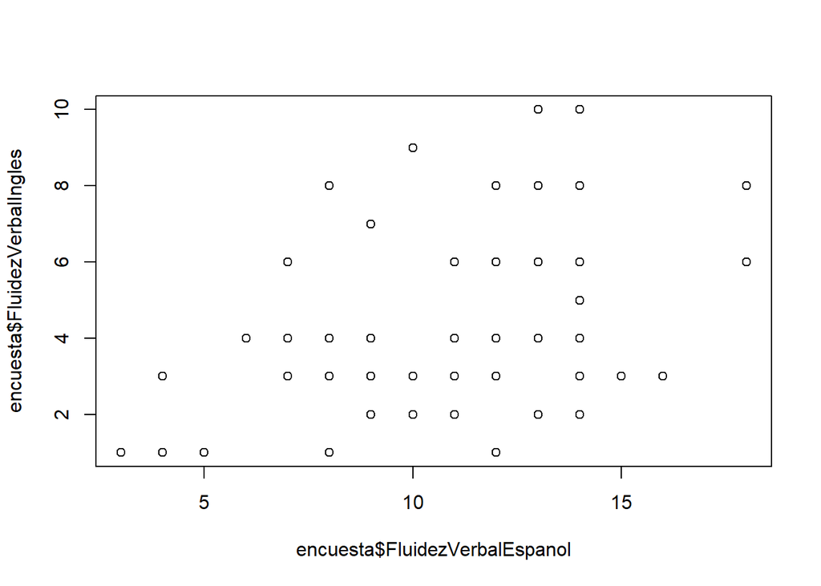

Trazamos una recta de regresion donde se puede ver una posible relacion entre las variables

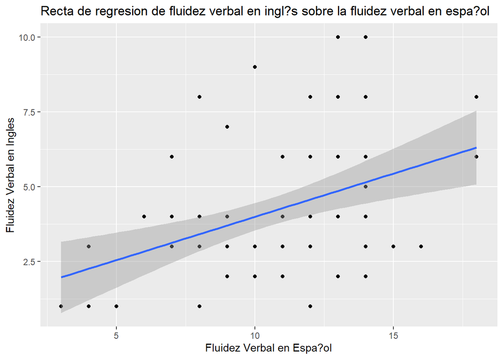

- Comprobando los supuestos Empezamos la comprobacion de los supuestos.

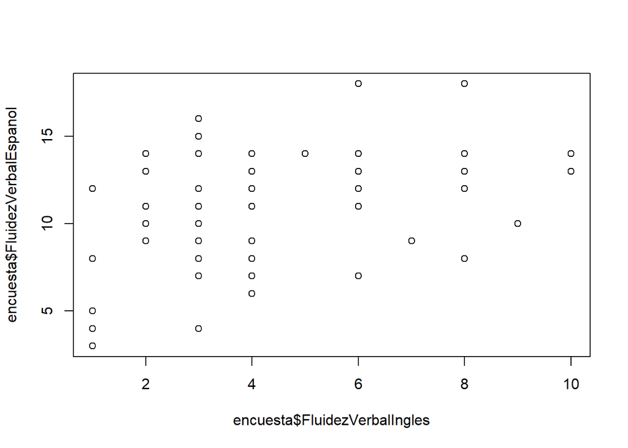

```r
plot(encuesta$FluidezVerbalIngles,encuesta$FluidezVerbalEspanol)
```

```r
cor.test(encuesta$FluidezVerbalIngles,encuesta$FluidezVerbalEspanol)
```

```
##
##  Pearson's product-moment correlation
##
## data:  encuesta$FluidezVerbalIngles and encuesta$FluidezVerbalEspanol
## t = 3.8425, df = 79, p-value = 0.0002447
## alternative hypothesis: true correlation is not equal to 0
## 95 percent confidence interval:
##  0.1954047 0.5661204
## sample estimates:
##       cor
## 0.3968231
```

```r
#manualmente:
Y <- 1.09690 + 0.28931 * 12; Y
```

```
## [1] 4.56862
```

```r
#con la funcion fitted
modelo <- lm(encuesta$FluidezVerbalIngles~encuesta$FluidezVerbalEspanol)

modelo$fitted.values #valores estimados de fluidez ingles para cada persona
```

[output not shown]

```r
#en base a los valores de fluidez en espa?ol
modelo$residuals#diferencia entre los valores estimados en fluidez ingles
```

[output not shown]

```r
#y los observados
```

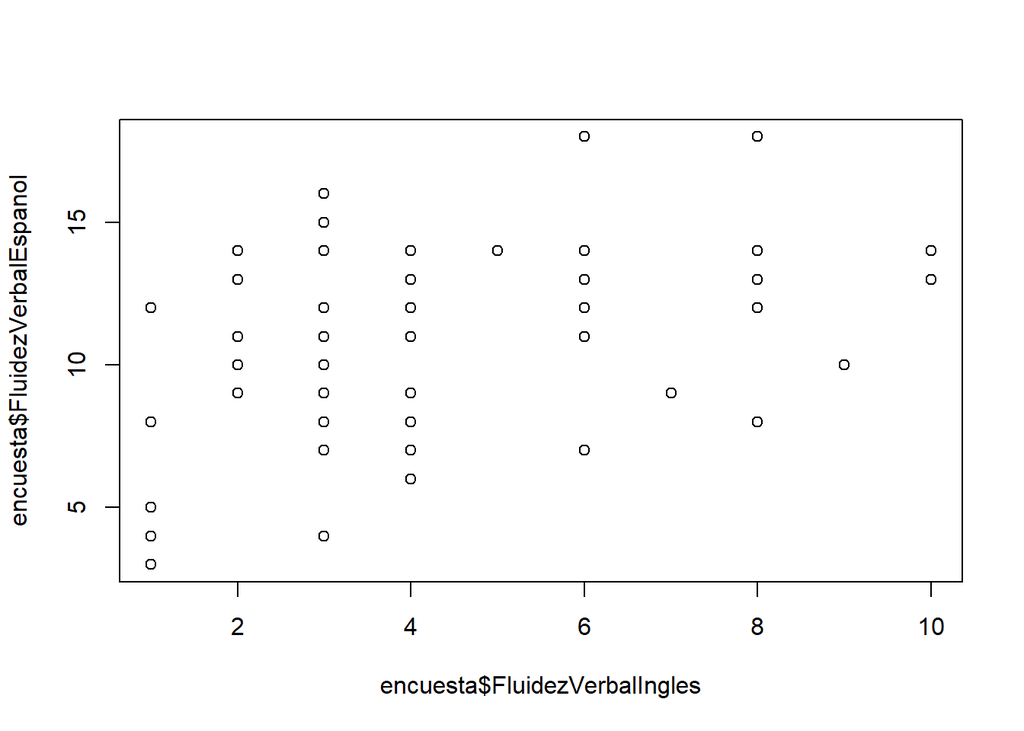

```r
#1.4. Comprueba los supuestos
##LINEALIDAD
plot(encuesta$FluidezVerbalIngles,encuesta$FluidezVerbalEspanol)
```

```r
cor.test(encuesta$FluidezVerbalIngles,encuesta$FluidezVerbalEspanol)
```

```
##
##  Pearson's product-moment correlation
##
## data:  encuesta$FluidezVerbalIngles and encuesta$FluidezVerbalEspanol
## t = 3.8425, df = 79, p-value = 0.0002447
## alternative hypothesis: true correlation is not equal to 0
## 95 percent confidence interval:
##  0.1954047 0.5661204
## sample estimates:
##       cor
## 0.3968231
```

- Normalidad. En los graficos se puede ver que la variable se ajusta relativamente bien a la curva. Sin embargo al aplicar el test de Kolmogorov, este rechaza la normalidad.

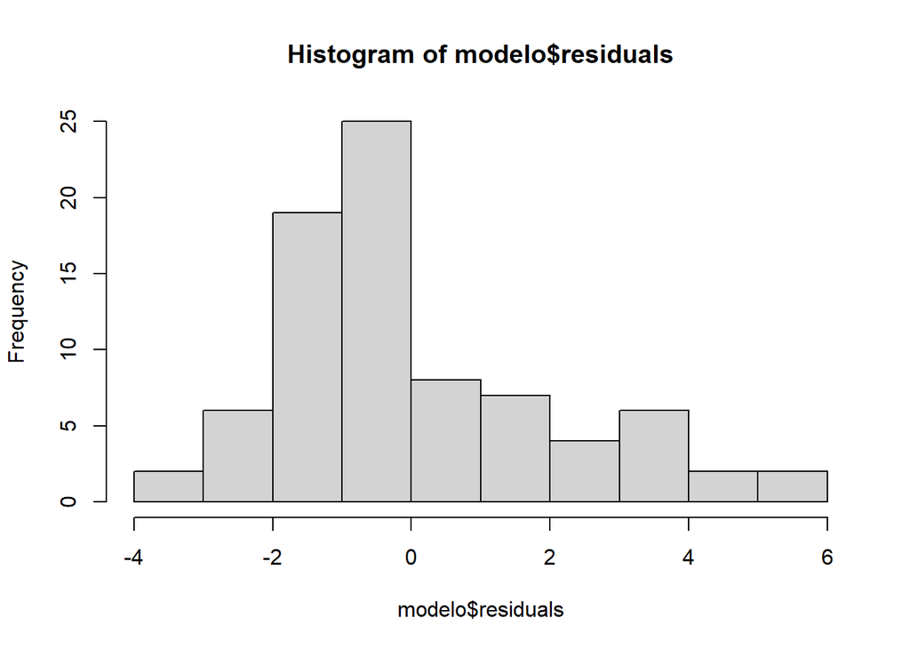

```r
##NORMALIDAD

hist(modelo$residuals)
```

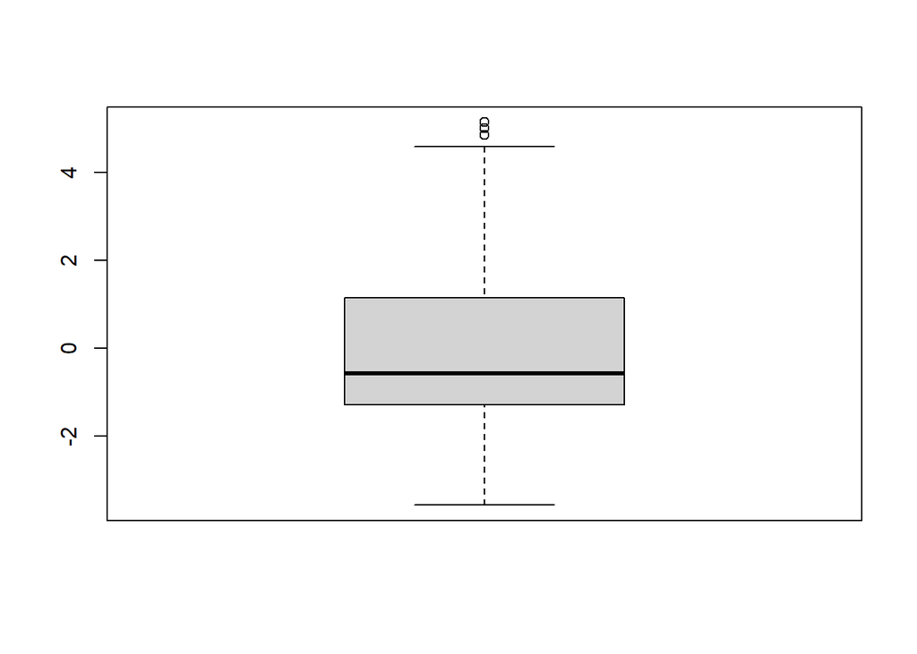

```r
boxplot(modelo$residuals)#mirar centro (mediana);
```

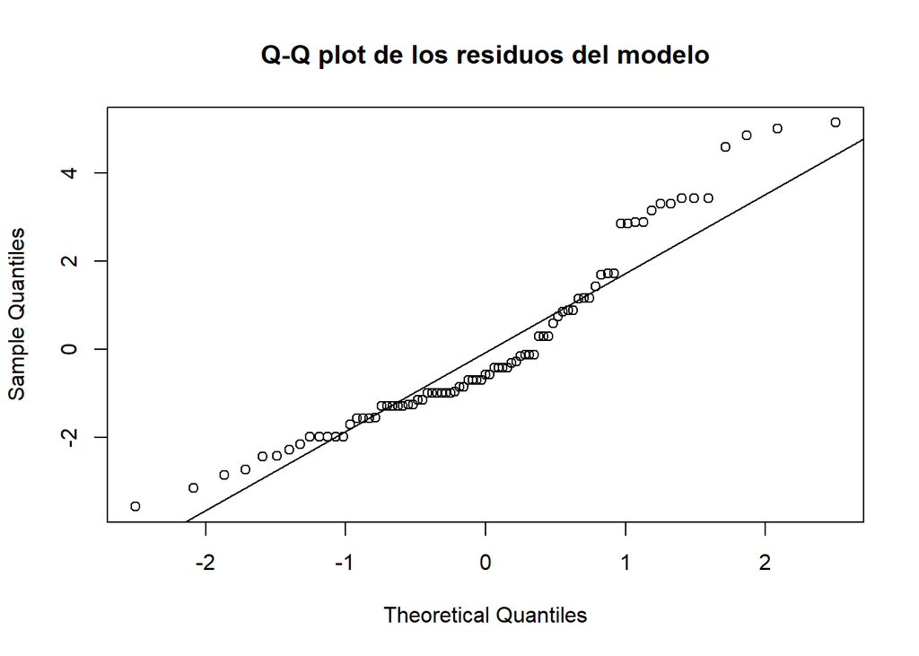

```r
#dispersi?n (bigote);
#casos at?picos o extremos

qqnorm(modelo$residuals, main="Q-Q plot de los residuos del modelo");qqline(modelo$residuals,distribution = qnorm)
```

```r
describe(modelo$residuals)#asimetria <2 y curtosis <7
```

```
##    vars  n mean   sd median trimmed  mad   min  max range skew kurtosis   se
## X1    1 81    0 2.04  -0.57   -0.18 1.48 -3.57 5.14  8.71 0.81    -0.12 0.23
```

```r
ks.test(modelo$residuals, "pnorm")
```

```
##
##  One-sample Kolmogorov-Smirnov test
##
## data:  modelo$residuals
## D = 0.25244, p-value = 6.571e-05
## alternative hypothesis: two-sided
```

```r
shapiro.test(modelo$residuals)#con muestras menores a 50
```

```
##
##  Shapiro-Wilk normality test
##
## data:  modelo$residuals
## W = 0.92388, p-value = 0.0001323
```

- Homocedasticidad. Dispersion de los pronosticos en base a los residuos la nube de puntos no queda aclaro que esta distribuida homogeneamente.

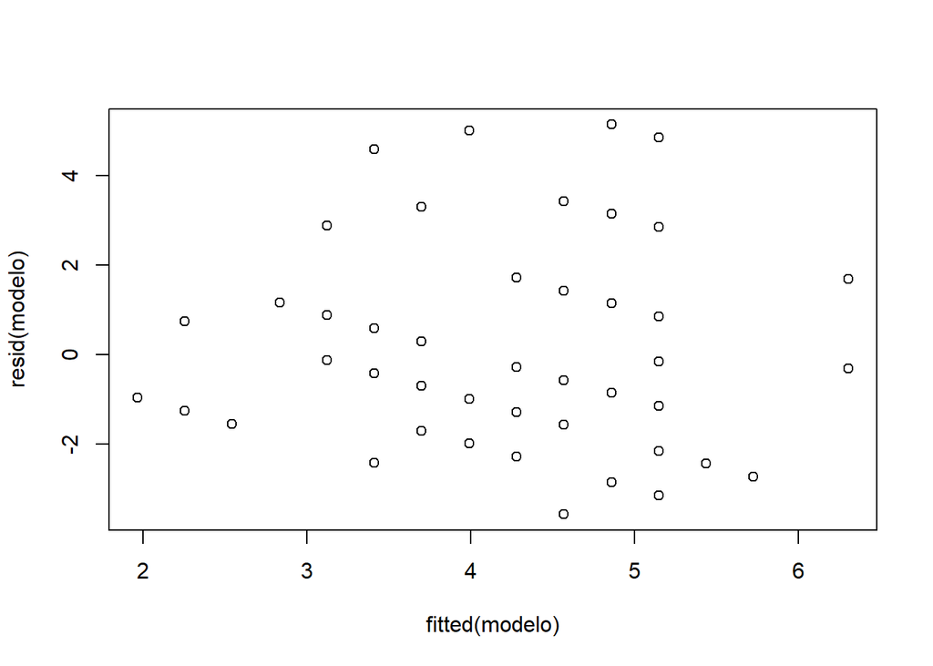

```r
##HOMOCEDASTICIDAD
plot(fitted(modelo),resid(modelo))
```

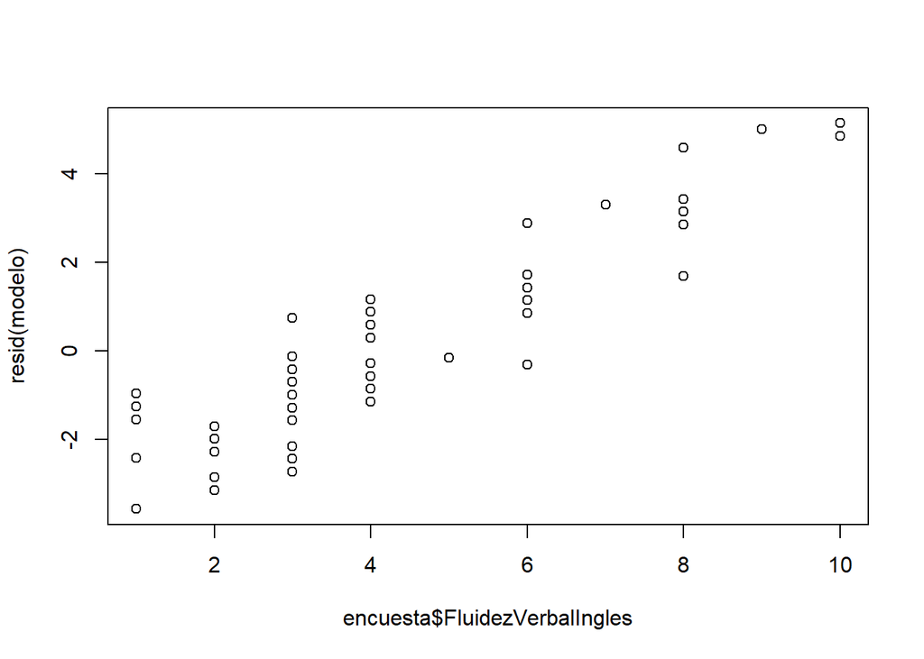

```r
##INDEPENDENCIA
plot(encuesta$FluidezVerbalIngles,resid(modelo))
```

```r
#los residuos no estan aleatoriamente repartidos
library(lmtest)
dwtest(modelo)#Durbin-Watson debe estar entre 1.5-2.5
```

```
##
##  Durbin-Watson test
##
## data:  modelo
## DW = 1.79, p-value = 0.1693
## alternative hypothesis: true autocorrelation is greater than 0
```